# **MLProjekt**

#### **HasCrCard**

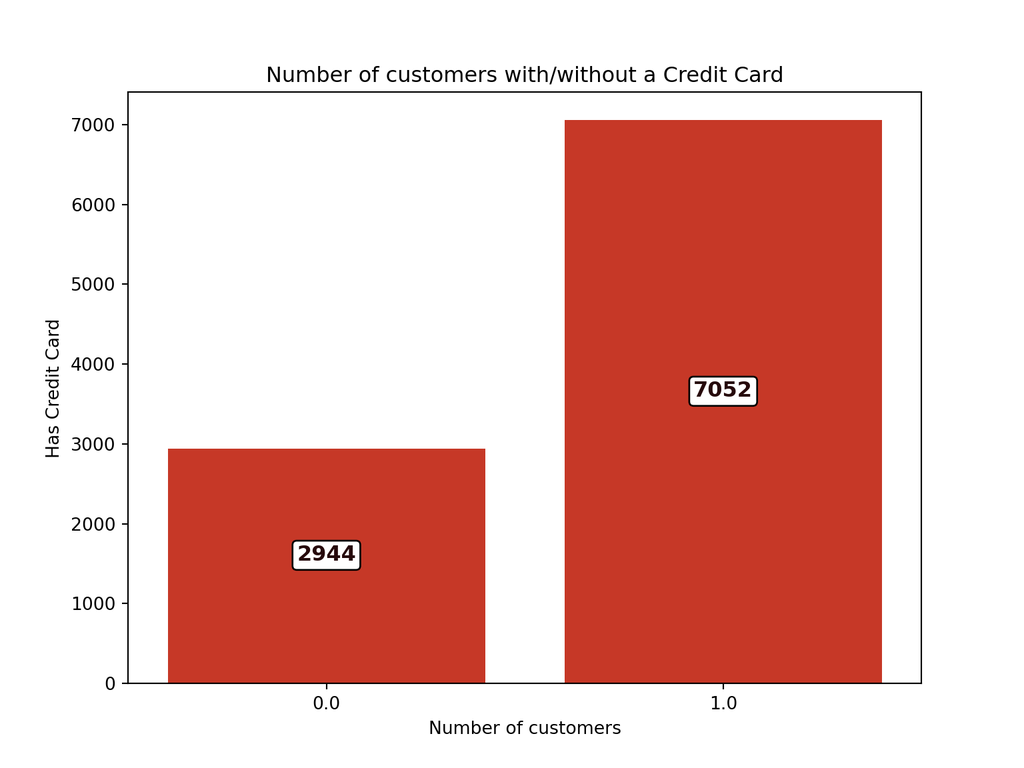

```python
plt.figure(figsize=(8,6))
p = sns.countplot(data=df, x='HasCrCard', orient='h', color=CLR)

for container in p.containers:
    plt.bar_label(container, label_type="center", color="#26090b", fontsize=12, weight='bold', padding=6,
                  bbox={"boxstyle": "round", "pad": 0.2, "facecolor": 'white', "alpha": 1})

plt.title('Number of customers with/without a Credit Card')
plt.xlabel('Number of customers')
plt.ylabel('Has Credit Card')
plt.show()
```

#### **IsActiveMember**

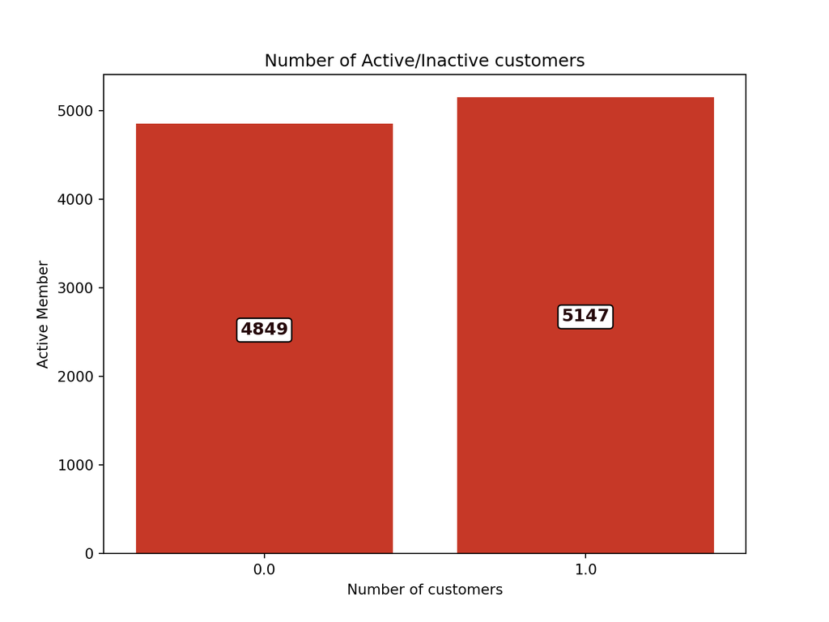

```python
plt.figure(figsize=(8,6))
p = sns.countplot(data=df, x='IsActiveMember', orient='h', color=CLR)

for container in p.containers:
    plt.bar_label(container, label_type="center", color="#26090b", fontsize=12, weight='bold', padding=6,
                  bbox={"boxstyle": "round", "pad": 0.2, "facecolor": 'white', "alpha": 1})

plt.title('Number of Active/Inactive customers')
plt.xlabel('Number of customers')
plt.ylabel('Active Member')
plt.show()
```

#### **Exited**

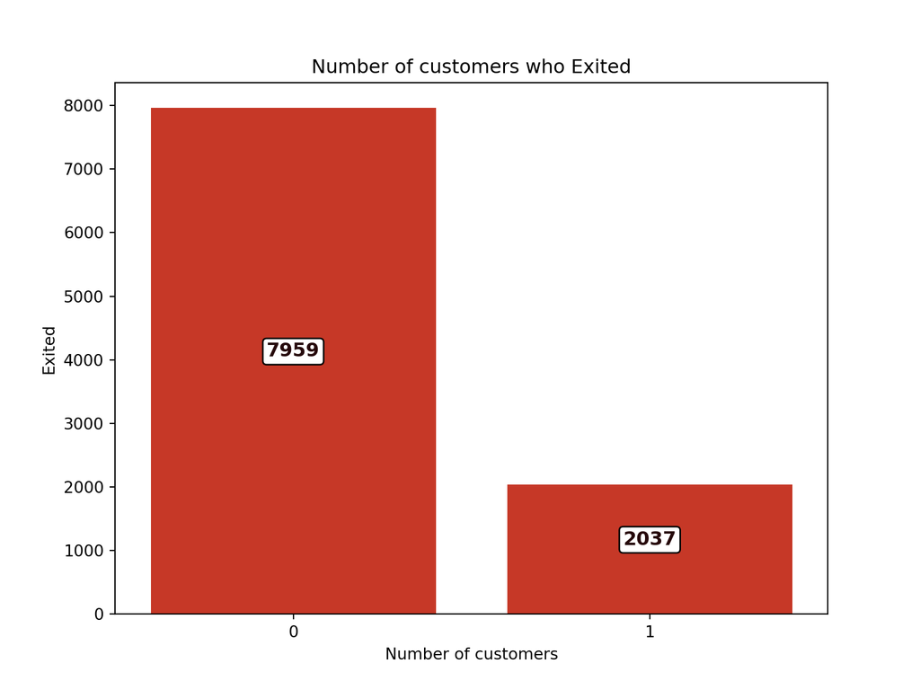

```python
plt.figure(figsize=(8,6))
p = sns.countplot(data=df, x='Exited', orient='h', color=CLR)

for container in p.containers:
    plt.bar_label(container, label_type="center", color="#26090b", fontsize=12, weight='bold', padding=6,
                  bbox={"boxstyle": "round", "pad": 0.2, "facecolor": 'white', "alpha": 1})

plt.title('Number of customers who Exited')
plt.xlabel('Number of customers')
plt.ylabel('Exited')
plt.show()
```

The dataset is highly imbalanced, with 80% of individuals staying with the bank and 20% choosing to leave.

#### **Age**

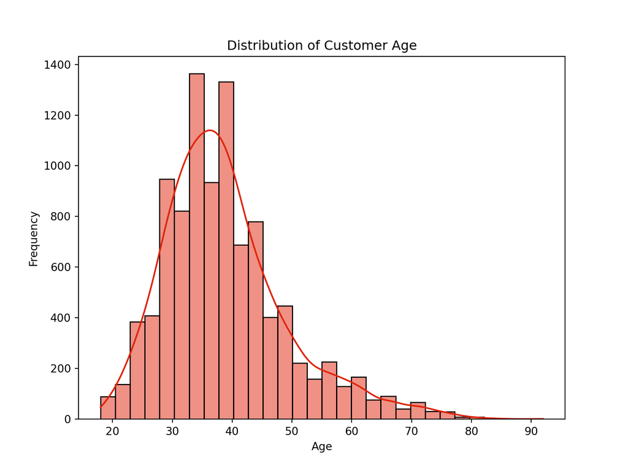

```python
plt.figure(figsize=(8,6))
sns.histplot(df['Age'], kde=True, color=CLR, bins=30)
plt.title('Distribution of Customer Age')
plt.xlabel('Age')
plt.ylabel('Frequency')

plt.show()
```

#### **Balance**

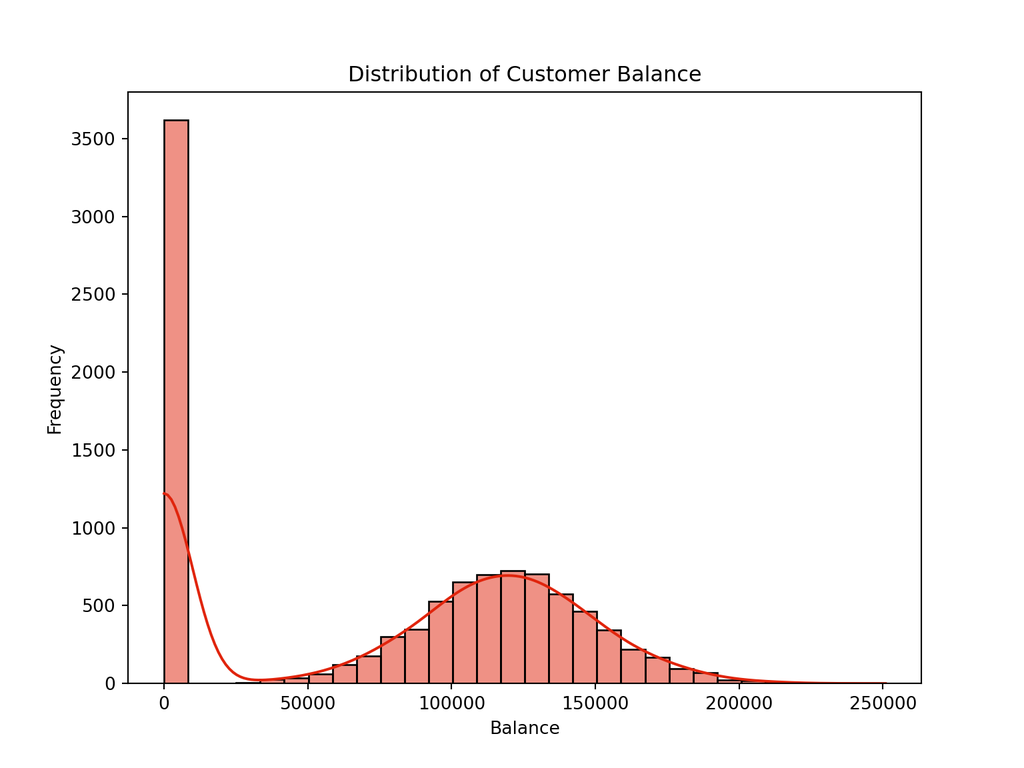

```python
plt.figure(figsize=(8,6))
sns.histplot(df['Balance'], kde=True, color=CLR, bins=30)
plt.title('Distribution of Customer Balance')
plt.xlabel('Balance')
plt.ylabel('Frequency')

plt.show()
```

The distribution of customer balances, excluding the value 0, resembles a normal distribution. The presence of a large number of accounts with a zero balance may suggest that these are inactive accounts or newly opened accounts.

#### **CreditScore**

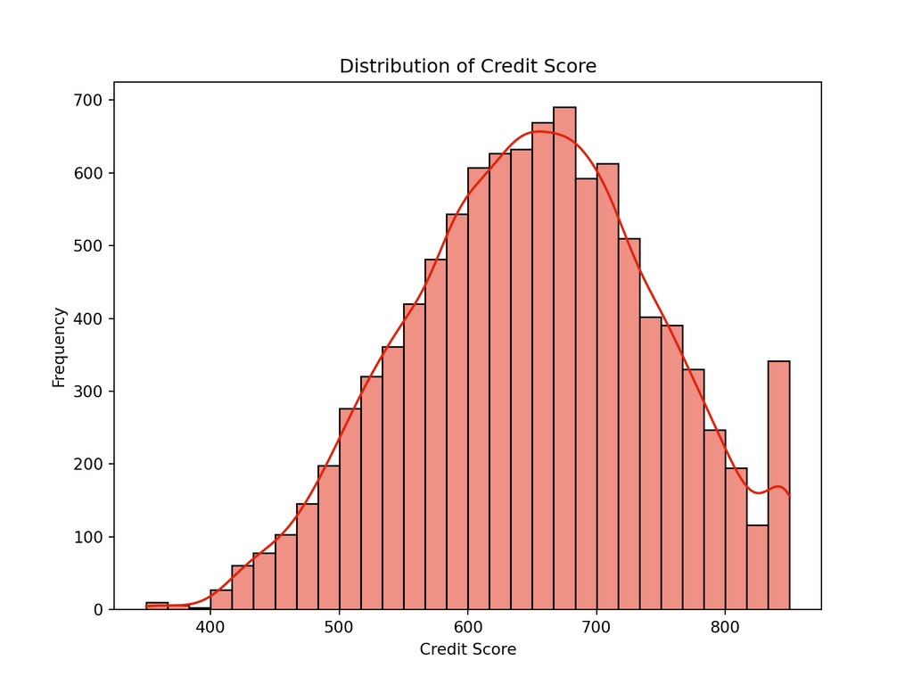

```python
plt.figure(figsize=(8,6))
sns.histplot(df['CreditScore'], kde=True, color=CLR, bins=30)
plt.title('Distribution of Credit Score')
plt.xlabel('Credit Score')
plt.ylabel('Frequency')

plt.show()
```

There is a concentration in the range of 600-700, suggesting that most individuals have moderately good credit scores. A smaller peak around 800-850 indicates the presence of a smaller group of customers with exceptionally high scores.

#### **EstimatedSalary**

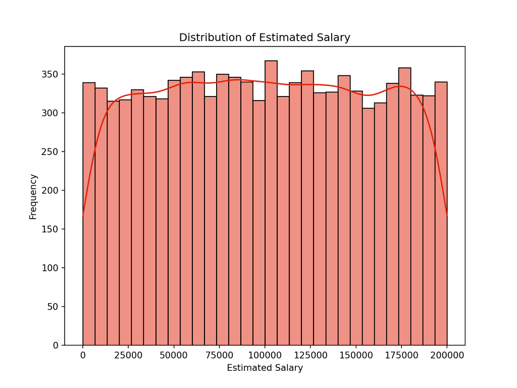

```python
plt.figure(figsize=(8,6))
sns.histplot(df['EstimatedSalary'], kde=True, color=CLR, bins=30)
plt.title('Distribution of Estimated Salary')
plt.xlabel('Estimated Salary')
plt.ylabel('Frequency')

plt.show()
```

The salaries follow a uniform distribution, with no strong concentration of salaries within a specific range. Salaries range from 0 to 200,000.

#### Visualizations by Target Variable

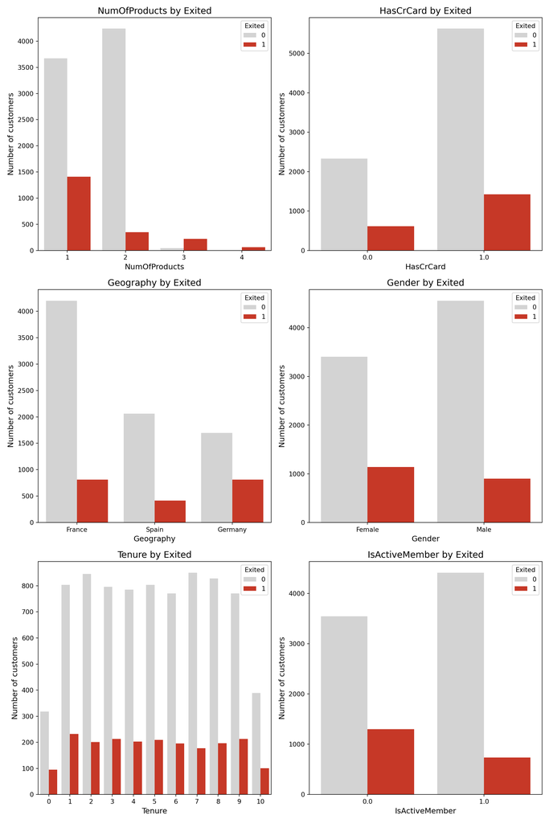

```python
fig, axes = plt.subplots(3, 2, figsize=(12, 18))  # 3 rows, 2 columns of subplots

variables = ['NumOfProducts', 'HasCrCard', 'Geography', 'Gender', 'Tenure', 'IsActiveMember']

for i, var in enumerate(variables):
    ax = axes[i//2, i%2]
    sns.countplot(data=df, x=var, hue='Exited', ax=ax, palette=['lightgray',CLR,])

    ax.set_title(f'{var} by Exited', fontsize=14)
    ax.set_xlabel(var, fontsize=12)
    ax.set_ylabel('Number of customers', fontsize=12)

plt.tight_layout()

plt.show()
```

### Outliers

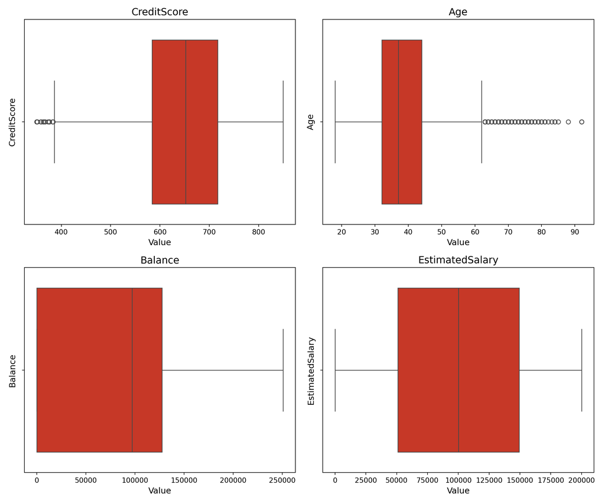

```python
fig, axes = plt.subplots(2, 2, figsize=(12, 10))

variables = ['CreditScore', 'Age', 'Balance', 'EstimatedSalary']

for i, var in enumerate(variables):
    ax = axes[i//2, i%2]
    sns.boxplot(data=df, x=var, ax=ax, color=CLR)

    ax.set_title(f'{var}', fontsize=14)
    ax.set_xlabel('Value', fontsize=12)
    ax.set_ylabel(var, fontsize=12)

plt.tight_layout()

plt.show()
```

Observations outside the whiskers of the box plots appear to be natural (e.g., in the case of age data) and provide additional insights into the data distribution, so we decide to keep them.

### Impact of the target variable

Correlations for the target variable with respect to quantitative variables were calculated using point-biserial correlation, while for binary and categorical variables, Cramér’s V coefficient was applied.

```python
continuous_vars = ['CreditScore','Age', 'Balance', 'EstimatedSalary', 'Tenure']
categorical_vars = ['Gender', 'HasCrCard', 'IsActiveMember','Geography', 'NumOfProducts']

correlation_results = {}

# Calculate Point-Biserial correlation for continuous variables
for var in continuous_vars:
    correlation, p_value = stats.pointbiserialr(df['Exited'], df[var])
    correlation_results[f'Exited vs {var} (Point-Biserial Correlation)'] = {'Score': correlation, 'p-value': p_value}

# Calculate V Cramers coefficient for categorical and binary variables
def cramers_v(confusion_matrix):
    chi2, p_value, dof, expected = stats.chi2_contingency(confusion_matrix)
    return np.sqrt(chi2 / (df.shape[0] * (min(confusion_matrix.shape) - 1)))

for var in categorical_vars:
    confusion_matrix = pd.crosstab(df['Exited'], df[var])
    cramers_v_val = cramers_v(confusion_matrix)
    correlation_results[f'Exited vs {var} (Cramér\'s V)'] = {'Score': cramers_v_val, 'p-value': None}

correlation_df = pd.DataFrame(correlation_results).T

correlation_df
```

```
##                                                        Score        p-value
## Exited vs CreditScore (Point-Biserial Correlation) -0.026975   6.994614e-03
## Exited vs Age (Point-Biserial Correlation)          0.285413  1.110675e-186
## Exited vs Balance (Point-Biserial Correlation)      0.118641   1.151085e-32
## Exited vs EstimatedSalary (Point-Biserial Corre...  0.011955   2.320463e-01
## Exited vs Tenure (Point-Biserial Correlation)      -0.014092   1.589010e-01
## Exited vs Gender (Cramér's V)                       0.106205            NaN
## Exited vs HasCrCard (Cramér's V)                    0.006847            NaN
## Exited vs IsActiveMember (Cramér's V)               0.155721            NaN
## Exited vs Geography (Cramér's V)                    0.173470            NaN
## Exited vs NumOfProducts (Cramér's V)                0.387786            NaN
```

These variables will likely have a significant impact on the classification.

## **Modeling**

We will build three models: KNN, SVM, and RandomForest, after preparing the data (balancing and standardization). For each algorithm, we will select the best model by performing hyperparameter tuning using GridSearchCV. The model evaluation will be based on accuracy calculated using 5-fold cross-validation.

### Train-Test split

80% - Training set  
20% - Test set

```python
X = df.drop(['Exited'], axis=1)
y = df['Exited']

X_train, X_test, y_train, y_test = train_test_split(X, y, test_size=0.2, random_state=42)
```

### KNN

The data has been balanced using the SMOTENC algorithm, which is adapted for categorical variables, and then standardized. The categorical variable columns have been encoded using one-hot encoding.

Pipeline:

- SMOTENC
- StandardScaler
- OneHotEncoder
- KNN

Grid of tested parameters:

- ‘n_neighbors’: [3, 5, 7, 9, 11, 13, 15, 17, 19]
- ‘weights’: [‘uniform’, ‘distance’]
- ‘p’: [1, 2]

```python
#KNN
scoring = {
    'accuracy': 'accuracy',
    'recall': make_scorer(precision_score),
    'specificity': make_scorer(recall_score, pos_label=0, average='weighted')
}

param_grid_knn = {
    'classifier__n_neighbors': [3, 5, 7, 9, 11, 13, 15, 17, 19],
    'classifier__weights': ['uniform', 'distance'],
    'classifier__p': [1, 2]  # p=1 for Manhattan distance, p=2 for Euclidean distance
}

encoder_scaler = ColumnTransformer(
    transformers=[
        ('onehot', OneHotEncoder(handle_unknown='ignore'), ['Geography', 'Gender', 'NumOfProducts']),
        ('scaler', StandardScaler(), ['CreditScore', 'Age', 'Balance', 'EstimatedSalary'])
    ],
    remainder='passthrough'
)

categorical_features=['Gender','HasCrCard','IsActiveMember','Geography','NumOfProducts']

pipeline_knn = Pipeline_imb([
    ('smote', SMOTENC(random_state=42, categorical_features=categorical_features)),
    ('encoder_scaler', encoder_scaler),
    ('classifier', KNeighborsClassifier())
])

grid_search_knn = GridSearchCV(pipeline_knn, param_grid_knn, cv=5, scoring=scoring, refit='accuracy', n_jobs=-1)
grid_search_knn.fit(X_train, y_train)
```

```
GridSearchCV(cv=5,
             estimator=Pipeline(steps=[('smote',
                                        SMOTENC(categorical_features=['Gender',
                                                                      'HasCrCard',
                                                                      'IsActiveMember',
                                                                      'Geography',
                                                                      'NumOfProducts'],
                                                random_state=42)),
                                       ('encoder_scaler',
                                        ColumnTransformer(remainder='passthrough',
                                                          transformers=[('onehot',
                                                                         OneHotEncoder(handle_unknown='ignore'),
                                                                         ['Geography',
                                                                          'Gender',
                                                                          'NumOfProducts']),
                                                                        ('scaler',
                                                                         StandardS...
                                                                          'EstimatedSalary'])])),
                                       ('classifier', KNeighborsClassifier())]),
             n_jobs=-1,
             param_grid={'classifier__n_neighbors': [3, 5, 7, 9, 11, 13, 15, 17,
                                                     19],
                         'classifier__p': [1, 2],
                         'classifier__weights': ['uniform', 'distance']},
             refit='accuracy',
             scoring={'accuracy': 'accuracy',
                      'recall': make_scorer(precision_score),
                      'specificity': make_scorer(recall_score, pos_label=0, average=weighted)})
```

```python
print("Best parameters found:", grid_search_knn.best_params_)
```

```
## Best parameters found: {'classifier__n_neighbors': 13, 'classifier__p': 1, 'classifier__weights': 'distance'}
```

```python
print("Best cross-validation accuracy:", grid_search_knn.best_score_)
```

```
## Best cross-validation accuracy: 0.7717588336460288
```

```python
print("Test set accuracy:", grid_search_knn.score(X_test, y_test))
```

```
## Test set accuracy: 0.773
```

### SVM(rbf kernel)

For this algorithm, better results are achieved by balancing the data using the SMOTE algorithm on the already encoded categorical data in one-hot encoding format, rather than applying the SMOTENC algorithm first. This creates unnatural, synthetic observations where binary variables take values other than 0 and 1. However, due to better results, we decide to go with this solution.

Pipeline:

- OneHotEncoder
- StandardScaler
- SMOTE
- SVM

Grid of tested parameters:

- ‘C’: [0.1, 1, 10, 100, 1000]
- ‘gamma’: [1, 0.1, 0.01, 0.001, 0.0001]

```python
#SVM
param_grid_svm = {
    'classifier__C': [0.1, 1, 10, 100, 1000],
    'classifier__gamma': [1, 0.1, 0.01, 0.001, 0.0001]
}

pipeline_svm = Pipeline_imb([
    ('encode_scale', encoder_scaler),
    ('smote', SMOTE(random_state=42)),
    ('classifier', SVC(random_state=42, kernel='rbf'))
])


grid_search_svm = GridSearchCV(pipeline_svm, param_grid_svm, cv=5, scoring=scoring, refit='accuracy', n_jobs=-1)
grid_search_svm.fit(X_train, y_train)
```

```
GridSearchCV(cv=5,
             estimator=Pipeline(steps=[('encode_scale',
                                        ColumnTransformer(remainder='passthrough',
                                                          transformers=[('onehot',
                                                                         OneHotEncoder(handle_unknown='ignore'),
                                                                         ['Geography',
                                                                          'Gender',
                                                                          'NumOfProducts']),
                                                                        ('scaler',
                                                                         StandardScaler(),
                                                                         ['CreditScore',
                                                                          'Age',
                                                                          'Balance',
                                                                          'EstimatedSalary'])])),
                                       ('smote', SMOTE(random_state=42)),
                                       ('classifier', SVC(random_state=42))]),
             n_jobs=-1,
             param_grid={'classifier__C': [0.1, 1, 10, 100, 1000],
                         'classifier__gamma': [1, 0.1, 0.01, 0.001, 0.0001]},
             refit='accuracy',
             scoring={'accuracy': 'accuracy',
                      'recall': make_scorer(precision_score),
                      'specificity': make_scorer(recall_score, pos_label=0, average=weighted)})
```

```python
print("Best parameters found:", grid_search_svm.best_params_)
```

```
## Best parameters found: {'classifier__C': 1000, 'classifier__gamma': 0.01}
```

```python
print("Best cross-validation accuracy:", grid_search_svm.best_score_)
```

```
## Best cross-validation accuracy: 0.8289127579737336
```

```python
print("Test set accuracy:", grid_search_svm.score(X_test, y_test))
```

```
## Test set accuracy: 0.8345
```

### Random Forest

For the same reason as with SVM, the SMOTE algorithm was used to balance the data.

Pipeline:

Grid of tested parameters:

- ‘n_estimators’: [50, 100, 200, 300]
- ‘max_depth’: [None, 10, 20, 30]
- ‘min_samples_split’: [2, 5, 10, 15]
- ‘min_samples_leaf’: [1, 2, 5, 10]

```python
#RandomForest
param_grid_forest = {
    'classifier__n_estimators': [50, 100, 200, 300],
    'classifier__max_depth': [None, 10, 20, 30],
    'classifier__min_samples_split': [2, 5, 10, 15],
    'classifier__min_samples_leaf': [1, 2, 5, 10]
    }

encoder = ColumnTransformer(
    transformers=[
        ('onehot', OneHotEncoder(handle_unknown='ignore'), ['Geography', 'Gender', 'NumOfProducts'])
    ],
    remainder='passthrough'
)

pipeline_forest = Pipeline_imb([
    ('encode', encoder),
    ('smote', SMOTE(random_state=42)),
    ('classifier', RandomForestClassifier(random_state=42))
])


grid_search_forest = GridSearchCV(pipeline_forest, param_grid_forest, cv=5, scoring=scoring, refit='accuracy', n_jobs=-1)
grid_search_forest.fit(X_train, y_train)
```

```
GridSearchCV(cv=5,
             estimator=Pipeline(steps=[('encode',
                                        ColumnTransformer(remainder='passthrough',
                                                          transformers=[('onehot',
                                                                         OneHotEncoder(handle_unknown='ignore'),
                                                                         ['Geography',
                                                                          'Gender',
                                                                          'NumOfProducts'])])),
                                       ('smote', SMOTE(random_state=42)),
                                       ('classifier',
                                        RandomForestClassifier(random_state=42))]),
             n_jobs=-1,
             param_grid={'classifier__max_depth': [None, 10, 20, 30],
                         'classifier__min_samples_leaf': [1, 2, 5, 10],
                         'classifier__min_samples_split': [2, 5, 10, 15],
                         'classifier__n_estimators': [50, 100, 200, 300]},
             refit='accuracy',
             scoring={'accuracy': 'accuracy',
                      'recall': make_scorer(precision_score),
                      'specificity': make_scorer(recall_score, pos_label=0, average=weighted)})
```

```python
print("Best parameters found:", grid_search_forest.best_params_)
```

```
## Best parameters found: {'classifier__max_depth': 20, 'classifier__min_samples_leaf': 1, 'classifier__min_samples_split': 10, 'classifier__n_estimators': 100}
```

```python
print("Best cross-validation accuracy:", grid_search_forest.best_score_)
```

```
## Best cross-validation accuracy: 0.8605540963101939
```

```python
print("Test set accuracy:", grid_search_forest.score(X_test, y_test))
```

```
## Test set accuracy: 0.847
```

## **Model Comparison and Interpretation**

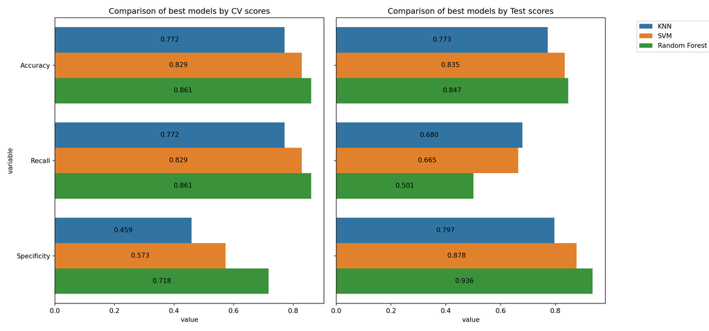

```python
def scores(y_true, y_pred):
    acc = accuracy_score(y_true, y_pred)
    rec = recall_score(y_true, y_pred)
    spe = recall_score(y_true, y_pred, pos_label=0)
    return [acc, rec, spe]

df_plot = pd.DataFrame(columns=['model', 'Accuracy', 'Recall', 'Specificity'])
df_plot2 = pd.DataFrame(columns=['model', 'Accuracy', 'Recall', 'Specificity'])

for (i,model), name in zip(enumerate([grid_search_knn, grid_search_svm, grid_search_forest]), ['KNN', 'SVM', 'Random Forest']):
    idx = model.best_index_
    cv_results = pd.DataFrame(model.cv_results_)
    res = cv_results[['mean_test_accuracy', 'mean_test_specificity', 'mean_test_recall']]
    df_plot.loc[i] = np.append(name, res.iloc[idx, :])
    df_plot2.loc[i] = np.append(name, scores(y_test, model.best_estimator_.predict(X_test)))

df_plot.iloc[:, 1:] = df_plot.iloc[:, 1:].astype(float)
df_plot2.iloc[:, 1:] = df_plot2.iloc[:, 1:].astype(float)


fig, axes = plt.subplots(1, 2, figsize=(15,7),sharey=True)

# Plot for CV scores
sns.barplot(data=df_plot.melt(id_vars='model'), y='variable', x='value', hue='model', orient='h', ax=axes[0], legend = False)
axes[0].set_title('Comparison of best models by CV scores')
for container in axes[0].containers:
    axes[0].bar_label(container, fmt='%.3f', label_type='center')

# Plot for test scores
sns.barplot(data=df_plot2.melt(id_vars='model'), y='variable', x='value', hue='model', orient='h', ax=axes[1])
axes[1].set_title('Comparison of best models by Test scores')
axes[1].legend(loc='upper right', bbox_to_anchor=(1.4, 1))
for container in axes[1].containers:
    axes[1].bar_label(container, fmt='%.3f', label_type='center')

plt.tight_layout()
plt.show()
```

Random Forest achieved the best results on the training set, obtaining the highest values for most cross-validation metrics such as Accuracy, Recall, and Specificity.

The Random Forest model, despite having the highest Accuracy, achieved the lowest Recall, meaning it performs the worst in identifying positive cases. KNN and SVM models perform better in this regard, but KNN has a significantly lower overall effectiveness. Therefore, the SVM model was selected as the final model.

## **Interpretality of SVM**

### Variable impact

```python
explainer = dx.Explainer(grid_search_svm.best_estimator_, X_test, y_test, label="SVM Model")
```

```python
vi = explainer.model_parts()
```

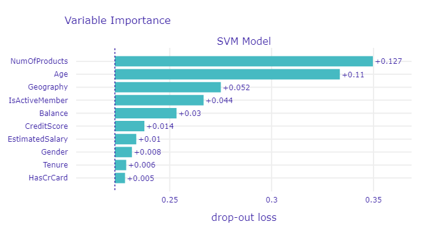

```python
plt = vi.plot(show=False)

# make plot static to show in html
plt = go.Figure(plt)

plt.write_image("vi_plot.png", engine="kaleido")
```

In the analyzed SVM model, the number of products owned and the age of the customer have by far the greatest impact on predictions. Slightly smaller, but still significant, are the geographic location and active membership status. Other variables, such as credit score, salary, gender, credit card ownership, and tenure, have a much smaller influence on the model’s results.

### Partial Dependence Plots

Partial dependence plots show how the prediction changes on average as one feature varies while keeping the other features constant.

#### PDP for Categorical Variables

```python
for var in categorical_features:
    X_test[var] = X_test[var].astype('category')
pd_profile_cat = explainer.model_profile(variables=categorical_features, type='partial', variable_type='categorical')
```

```python
pd_profile_cont = explainer.model_profile(variables=['CreditScore','Age','Tenure','Balance','EstimatedSalary'], type='partial')
```

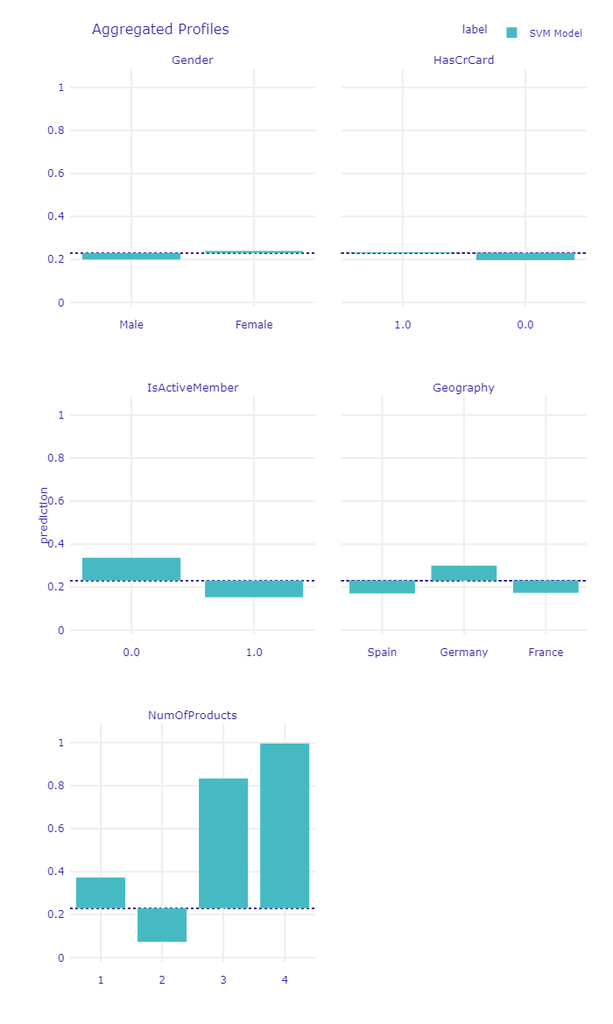

```python
# make plot static to show in html
plt2 = go.Figure(pd_profile_cat.plot(show=False))
plt3 = go.Figure(pd_profile_cont.plot(show=False))
plt2.write_image("pdpcat_plot.png", engine="kaleido")
plt3.write_image("pdpcont_plot.png", engine="kaleido")
```

It can be observed that the variable NumOfProducts has the greatest impact on predictions. Values of 3 and 4 for this variable strongly indicate customer churn (Exited = 1). This observation is consistent with the results presented in the EDA chapter. The frequency distribution plot for this variable showed that when NumOfProducts is 3 or 4, nearly all observations had the target variable (Exited) equal to 1. The V-Cramer value was also high.

Another significant variable appears to be IsActiveMember.

The remaining categorical variables have little impact on predictions.

#### PDP for Quantitative Variables

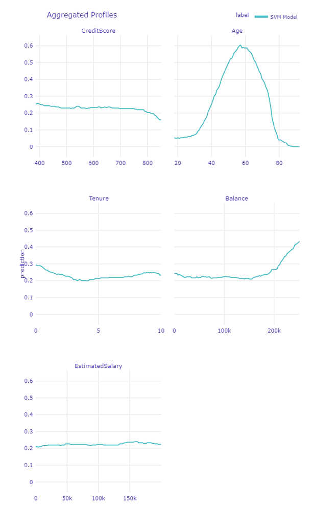

The values of the variables CreditScore, Tenure, and EstimatedSalary do not have a significant impact on the prediction, as they remain relatively constant. On the other hand, the variables Age and Balance show a significant influence. The closer the customer is to the age of 55, the higher the likelihood of churn. For Balance, in the upper range (above 180k), it can be observed that the higher the account balance, the greater the risk of customer departure.

### Average SHAP Values

Let’s now check how individual features affect the predictions for a single random observation.

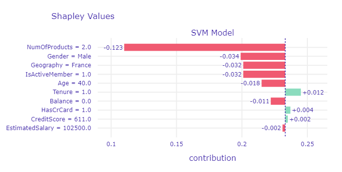

```python
observation = X_test.iloc[[555]]
shap = explainer.predict_parts(observation, type = 'shap')
plt5 = go.Figure(shap.plot(show=False))
plt5.write_image("plt5shap_plot.png", engine="kaleido")
```

As seen in the PDP plots, for the most important variable NumOfProducts, a value of 2 indicates the lowest likelihood of customer churn. This aligns with the SHAP plot, where this feature primarily determined the prediction decision.

## **Summary**

The project aimed to analyze the phenomenon of customer churn in the banking sector. The “The bank customer churn dataset” was used. The main task was to examine the factors influencing a customer’s decision to leave and to create machine learning models to predict this phenomenon.